# Final Project - WQU Python II

Contents

- Running the code
- Assumptions - defines the problem
- Real Data - shows how the real data set fitts to the assumptions
  - Log Returns - this section deals with log returns - normal distribution assumption
    - Fat Tail Note
  - Prices - this section deals with prices - log normal distribution assumption
- Extreme events - market crashes
- Fractal Model of Market
- Conclusion - this is a final note.
- Functions - contains all necessary function used in above sections
  - b_motion - Brownian Motion
  - describe_array - return statistical description for data
  - normality_tests - Normality Tests for Numpy Array
  - plot_cumulative_returns - simple Pandas plot
  - normality_tests_for_df - the same as normality_tests but you can pass in a dataframe
  - QQ plot function - prints QQ plot for a np.array object
  - Plot histogram - plots histogram and adds a fitted normal distribution line
  - Plot price histogram and log price histogram - shows histogram and log of histogram with fitted distributions
  - Extreme event probability - cdf - this is just a wrapper for normal cdf function
  - Extreme event probability - pdf - this is just a wrapper for normal cdf function
  - Fractal Model of Market

## Running the code.

Please note that I switched off a lot of the plotting when running the code as it would too many plots to close after the code finishes. There is a simple if statement to control this in the main program.

```python
#%% Import libaries
%matplotlib inline

import pandas as pd
import numpy as np
np.random.seed(1000)
import scipy.stats as scs
import statsmodels.api as sm
import matplotlib as mpl
import matplotlib.pyplot as plt
import seaborn as sns
mpl.style.use('ggplot')
```

## Assumptions

As stated in the assignment, many models in quantitative finance assume that the return follow normal distribution and prices follow log normal distribution. I will focus on log return in this project as this is where the assumption is made. Let's have a look at the consequence of the assumptions.

This part is based on the course text book by Yves Hilpisch. We will generate some data based on the assumptions of normally distributed log returns using Brownian motion and will demostrate the tools for determining the normality of a data set.

```python
# define some data for the geometric Brownian motion
"""
    :param: S0 : float - initial stock/index value

    :param: r : float - constant short rate

    :param: sigma : float - constant volatility

    :param: T : float - final time horizon

    :param: M : int - number of time steps/intervals

    :param: I : int - number of paths to be simulated
"""

S_0 = 100.
r = 0.05
sigma = 0.2
T = 1.0
M = 50
I = 250000
```

```python
# generate the paths using the Brownian motion
paths = b_motion(S_0, r, sigma, T, M, I)
```

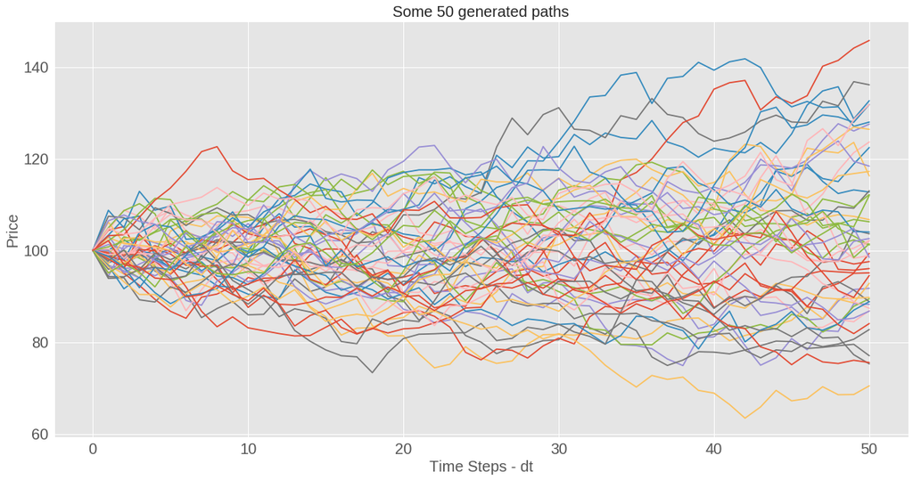

```python
# show the generated paths
plt.figure(figsize=(20,10))
plt.plot(paths[:,:50])
plt.title('Some 50 generated paths',fontsize=20)
plt.xlabel('Time Steps - dt',fontsize=20)
plt.ylabel('Price',fontsize=20)
```

I have shown 50 of the paths because we can start seeing the properties of the log normal distirbution from the plot. There are no jumps in the price and the prices somewhat resemble the of log normal distribution in its evolution. The more paths we would get, the more the log normal distribution would show up.

We proceed by calculating the log returns and statistically describing them.

```python
# get returns for the simulated price paths
log_returns = np.log(paths[1:] / paths[0:-1])
describe_array(log_returns.flatten())
```

```
     statistic           value
------------------------------
          size        12500000
           min        -0.14194
           max         0.14227
          mean         0.00060
           std         0.02828
          skew         0.00020
      kurtosis         0.00030
```

We can see that the distribution of the is likely to be normal as the distribution shows only very small skew and kurtosis. This is due to the fact that we are running a Monte Carlo simulation so some small error is expected.

QQ plots shows how well the data follows normal distribution.

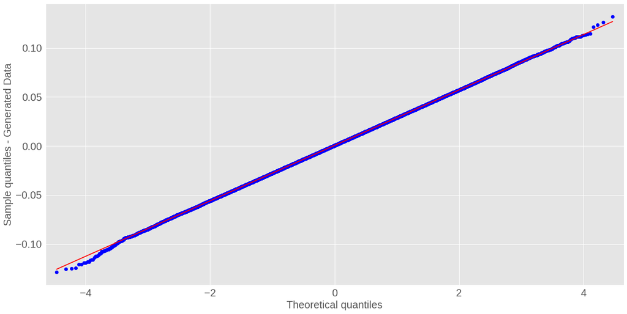

```python
# show QQ plot
qq_plot(log_returns[::700],'Generated Data')
```

The way to interpret the QQ plot is that we look the straigt line that represents the theoretical normal distribution and compare the actual data points to the theoretical line. The theoretical quantiles would tranlate to the actual data as a straigt line. If this is not the case, we have a skew or tails in the distribution.

We also can perform normality tests to see if the data set fits the normal distribution.

```python
# test for normality
normality_tests(log_returns.flatten())
```

```
         Description             value/p-value
--------------------------------------------------
         Skew of data set         0.00020
        Skew test p-value         0.77553
         Kurt of data set         0.00030
        Kurt test p-value         0.82705
        Norm test p-value         0.93751
```

In this case, we can see that all p values are higher than 5%. So, we can be strongly condifident that the log return set as generated by the Geometric Brownina Motion are indeed normally distributed. This is exactly what the assumption is.

We can plot the distribution of the data as below.

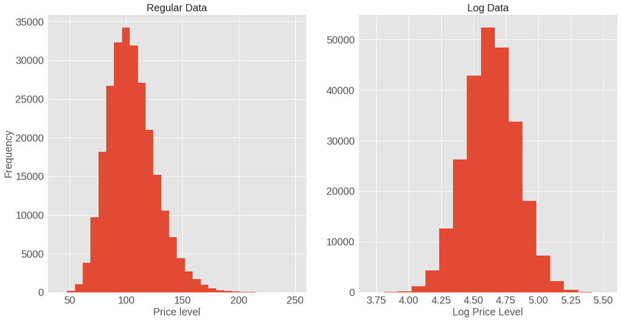

```python
f, (ax1, ax2) = plt.subplots(1,2, figsize=(20,10))
ax1.hist(paths[-1], bins=30)
ax1.grid(True)
ax1.set_xlabel('Price level',fontsize=20)
ax1.set_ylabel('Frequency',fontsize=20)
ax1.set_title('Regular Data',fontsize=20)
ax2.hist(np.log(paths[-1]), bins=17)
ax2.grid(True)
ax2.set_xlabel('Log Price Level',fontsize=20)
ax2.set_title('Log Data',fontsize=20)
```

We can also use the seaborn package as below. We have just ploted the log normal and normal PDFs based on the generated data.

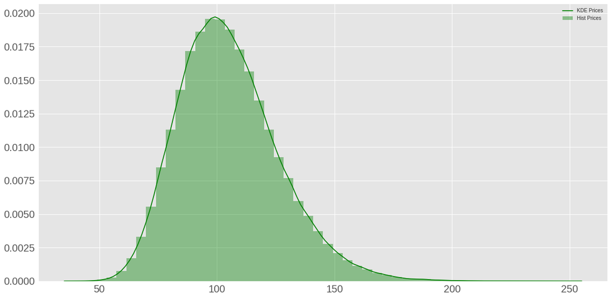

```python
plt.figure(figsize=(20,10))
sns.distplot(paths[-1], color="g", kde_kws={"label": "KDE Prices"}, hist_kws={"label": "Hist Prices"})
```

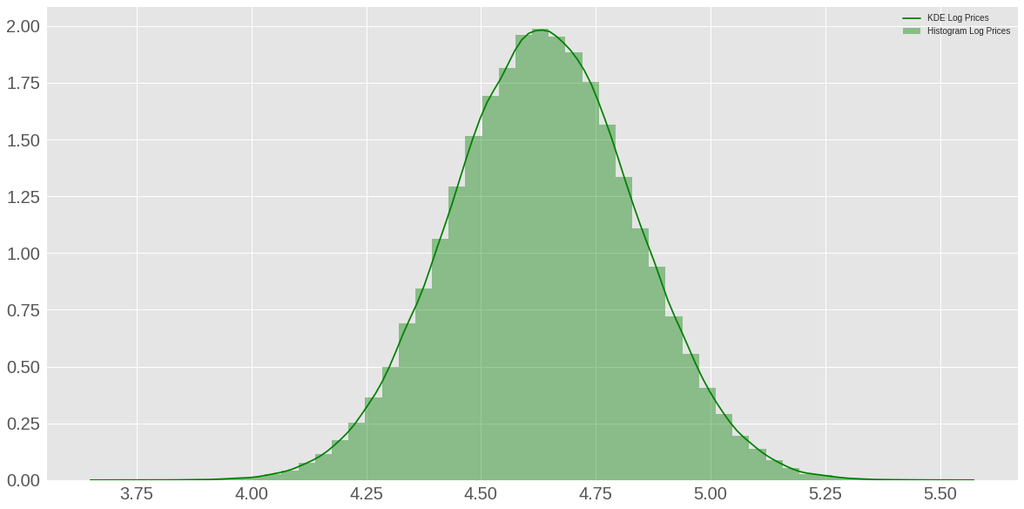

```python
plt.figure(figsize=(20,10))
sns.distplot(np.log(paths[-1]), color="g",
             kde_kws={"label": "KDE Log Prices"}, hist_kws={"label": "Histogram Log Prices"})
```

Of course we have to test the normality of the data.

These test are for the generated data are done below. We can see that the generated prices are skewed and have high kurtosis. These values are expected to log normally distributed values.

```python
describe_array(paths[-1])
```

```
     statistic           value
------------------------------
          size          250000
           min        40.54676
           max       249.66486
          mean       105.13186
           std        21.26712
          skew         0.61645
      kurtosis         0.66788
```

These are the prices in the log form. We can see the impact of taking the logs from the figures. In this case we have small skew and kurtosis. So, we see that the data is likely to be normally distributed.

```python
describe_array(np.log(paths[-1]))
```

```
     statistic           value
------------------------------
          size          250000
           min         3.70246
           max         5.52012
          mean         4.63517
           std         0.20020
          skew         0.00431
      kurtosis        -0.00767
```

To test whether we need have the prices follow the log normal distribution, we use the log form of the data.

```python
normality_tests(np.log(paths[-1]))
```

```
         Description             value/p-value
--------------------------------------------------
         Skew of data set         0.00431
        Skew test p-value         0.37874
         Kurt of data set        -0.00767
        Kurt test p-value         0.43624
        Norm test p-value         0.50134
```

So, we can see that the log of the generated prices is very likely to be normally distributed with small skew and kurtosis. We see that the assumption generally holds for the generated data. This is not surprising.

We are ready to handle real data sets.

## Real Data

I have downloaded the data using Bloomberg terminal at my work. Then I have prepared the data set manually in Excel. I found all unique dates from all indices and extended the index level for the non trading days by the index level from the previous business day.

For example, INDU Index was not trading on 07-Jul-1990 however the index on 06-Jul-1990 was 2,904.95. I moved this value to 07-Jul-1990, so the return for 09-Jul-1990 is based on the value from 07-Jul-1990. I will have to make sure that all zero returns are not considered in the statistical analysis.

I saved the data to CSV and it can be load using Pandas.

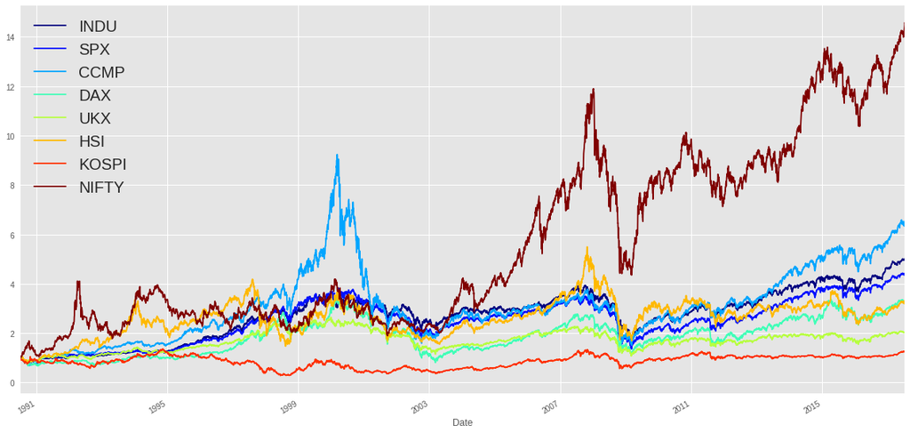

```python
# read in the data
data = pd.read_csv('BBergData.csv')
data.index = pd.to_datetime(data.Date)
data.drop('Date', axis=1, inplace=True)

#plot the cumulative log returns
plot_cumulative_returns(np.log(data[1:]/data.shift(1)))
```

### Log returns - Normal distribution Assumption

This section deal with the assumption of normal returns. We have to calculate the normality test for the real log returns to see if the actual retuns are normally distributed.

```python
# calculate the returns and drop the Nan line
log_returns_data = np.log(data[1:]/data.shift(1))[1:]

# calculate the log of the prices
log_data = np.log(data)

# print the describtion for the returns
log_returns_data.describe().style.format("{:5.5f}")
```

|  | INDU | SPX | CCMP | DAX | UKX | HSI | KOSPI | NIFTY |
| --- | --- | --- | --- | --- | --- | --- | --- | --- |
| count | 7473.00000 | 7473.00000 | 7473.00000 | 7473.00000 | 7473.00000 | 7473.00000 | 7473.00000 | 7473.00000 |
| mean | 0.00027 | 0.00026 | 0.00035 | 0.00025 | 0.00015 | 0.00028 | 0.00016 | 0.00048 |
| std | 0.01019 | 0.01071 | 0.01399 | 0.01368 | 0.01064 | 0.01514 | 0.01581 | 0.01541 |
| min | -0.08201 | -0.09470 | -0.10168 | -0.08875 | -0.09266 | -0.14735 | -0.12805 | -0.13054 |
| 25% | -0.00381 | -0.00380 | -0.00495 | -0.00557 | -0.00471 | -0.00576 | -0.00665 | -0.00585 |
| 50% | 0.00000 | 0.00000 | 0.00000 | 0.00000 | 0.00000 | 0.00000 | 0.00000 | 0.00000 |
| 75% | 0.00487 | 0.00497 | 0.00664 | 0.00674 | 0.00534 | 0.00688 | 0.00731 | 0.00756 |
| max | 0.10508 | 0.10957 | 0.13255 | 0.10797 | 0.09384 | 0.17247 | 0.11284 | 0.16334 |

```python
normality_tests_for_df(log_returns_data).style.format("{:5.5f}")
```

|  | INDU | SPX | CCMP | DAX | UKX | HSI | KOSPI | NIFTY |
| --- | --- | --- | --- | --- | --- | --- | --- | --- |
| Skew | -0.16295 | -0.24699 | -0.09823 | -0.13709 | -0.13153 | -0.01092 | -0.22600 | -0.12034 |
| SkewTest_pValue | 0.00000 | 0.00000 | 0.00095 | 0.00000 | 0.00001 | 0.71537 | 0.00000 | 0.00008 |
| Kurt | 8.28311 | 8.82078 | 6.29697 | 4.52300 | 5.98243 | 9.44969 | 4.89188 | 7.18177 |
| KurtTest_pValue | 0.00000 | 0.00000 | 0.00000 | 0.00000 | 0.00000 | 0.00000 | 0.00000 | 0.00000 |
| NormTest_pValue | 0.00000 | 0.00000 | 0.00000 | 0.00000 | 0.00000 | 0.00000 | 0.00000 | 0.00000 |

The skewness and kurtosis can be seen as a measure of degree of deviation from the normal distribution as skewness and kurtosis for the normal distribution is zero. We can see how far the empirical density deviates from the normal distribution.

We can show these results with QQ plots.

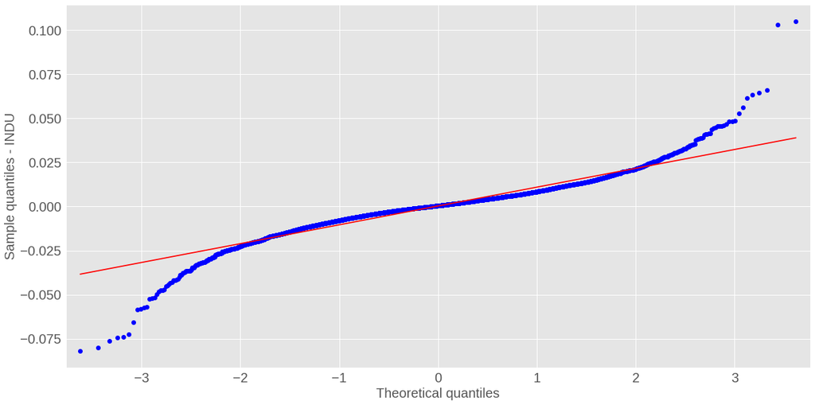

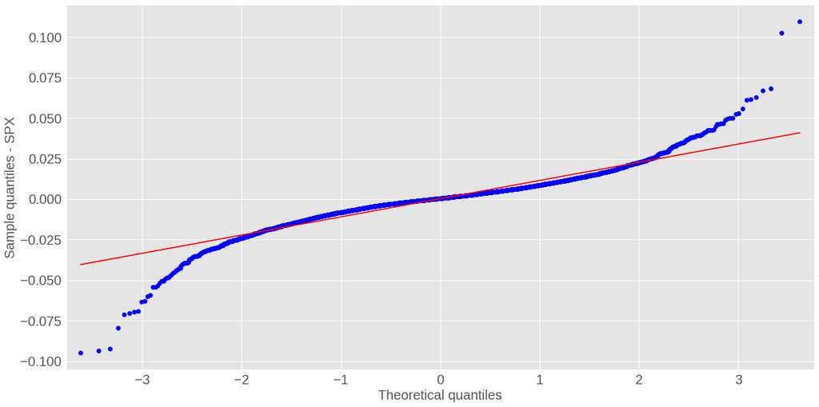

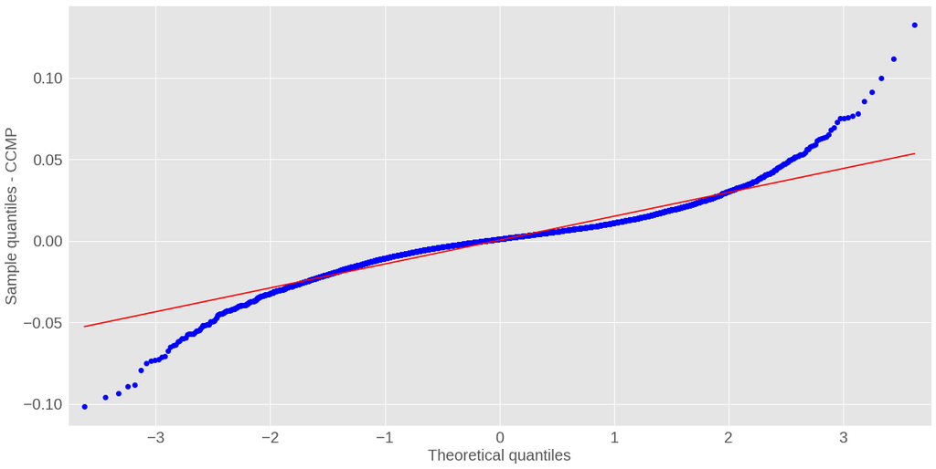

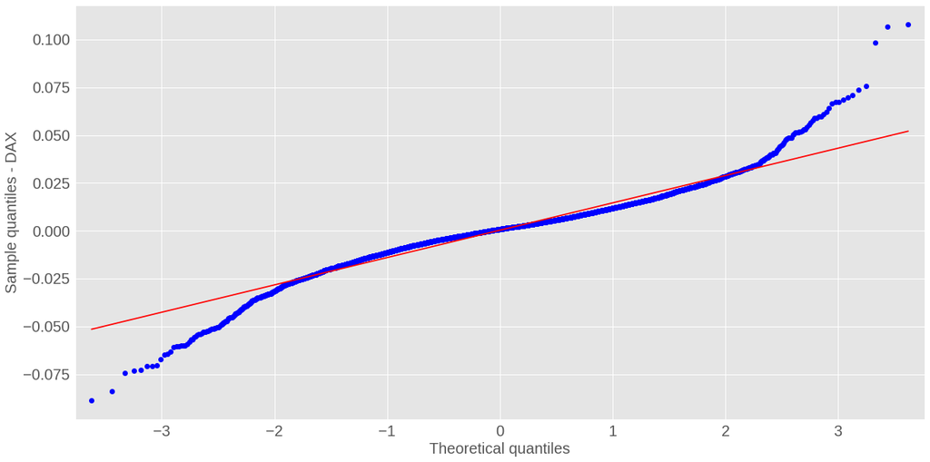

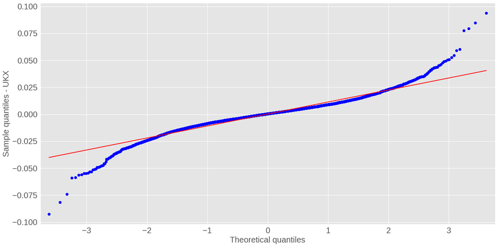

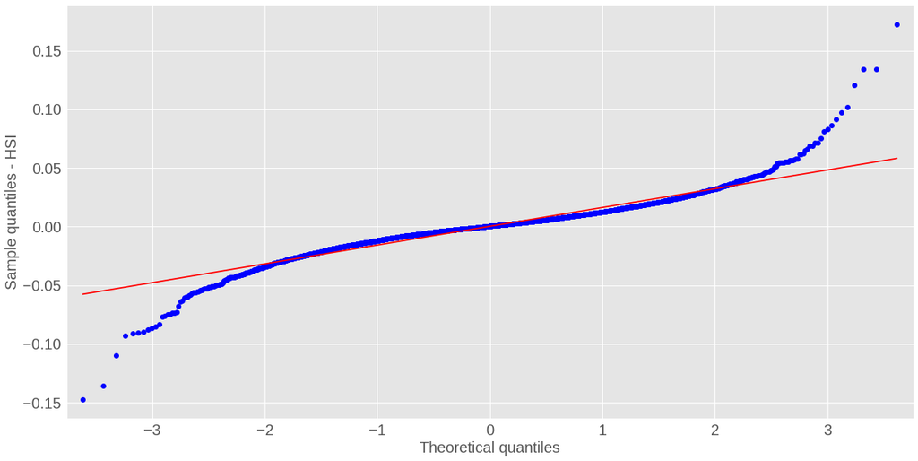

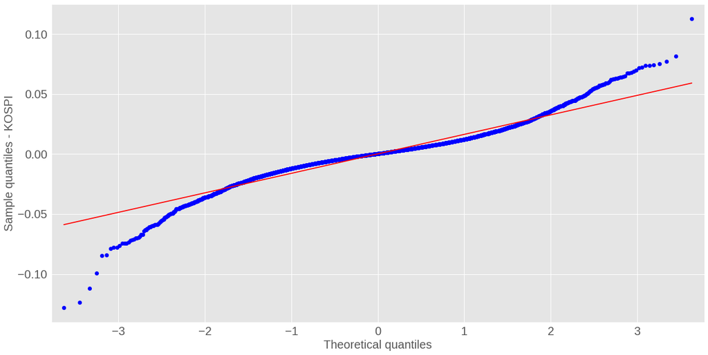

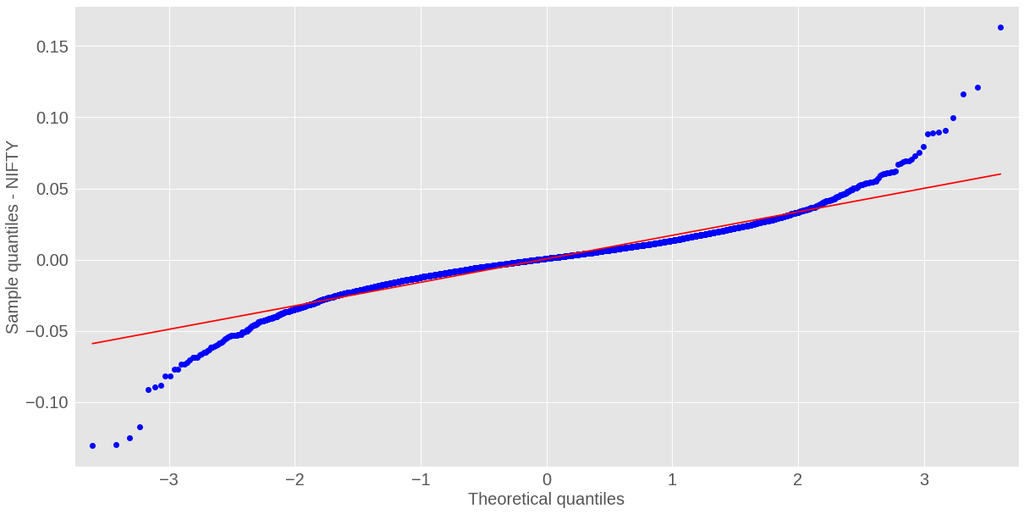

```python
for i in range(0,len(log_returns_data.columns)):
        qq_plot(log_returns_data.iloc[:,i].values, log_returns_data.columns.values[i])
```

#### Fat Tail Note

As stated above. We have ploted the fat tails for the empirical distributions using the QQ plots here.

We can also just print the distribution of return as histograms. The red line is the fitted normal distribution for comparison with the KDE.

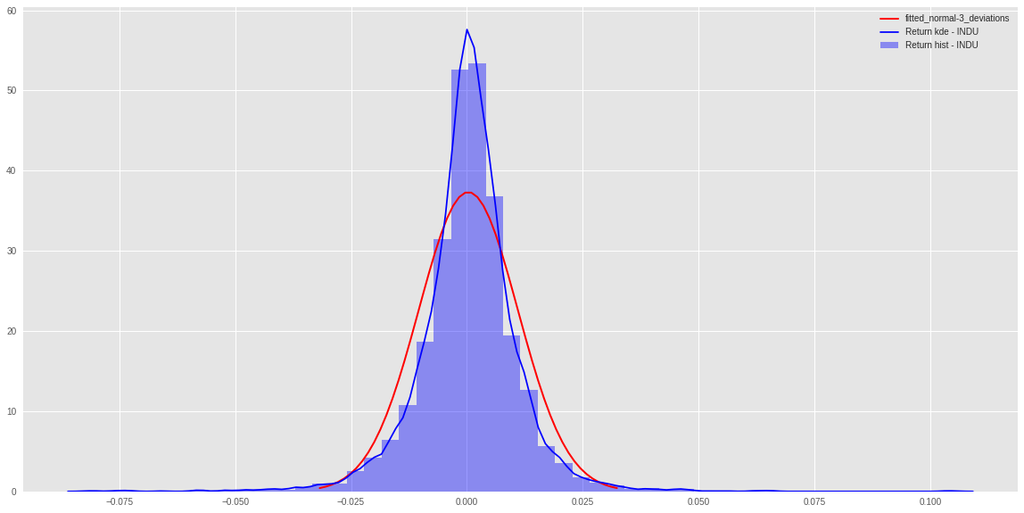

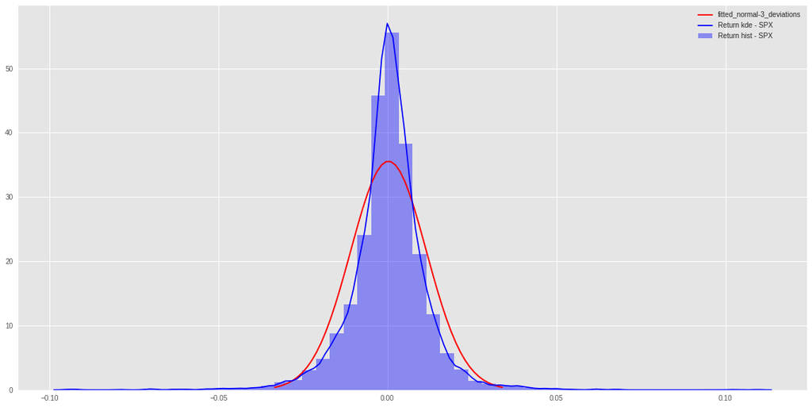

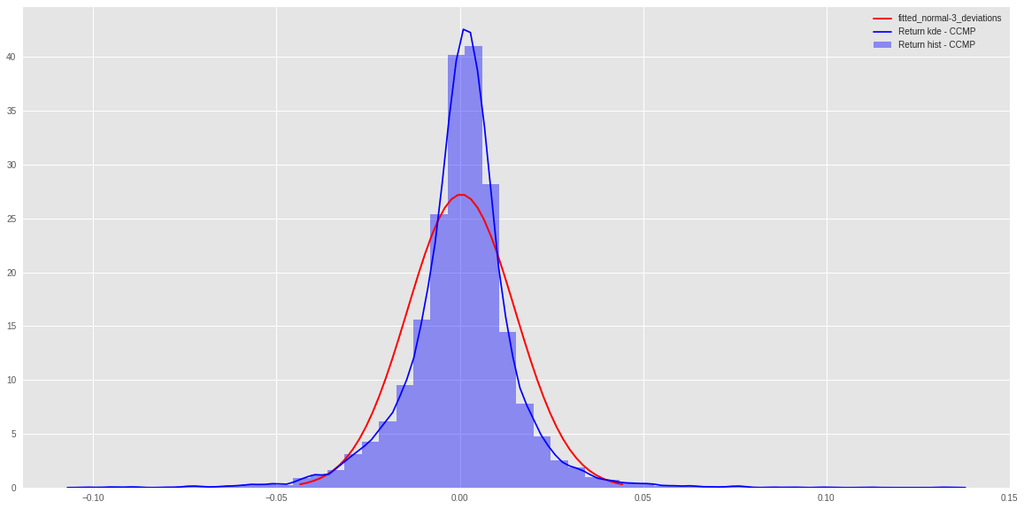

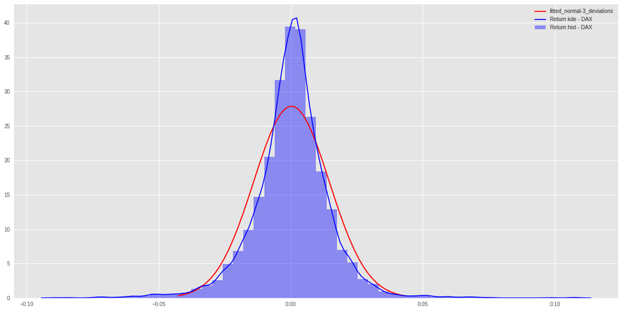

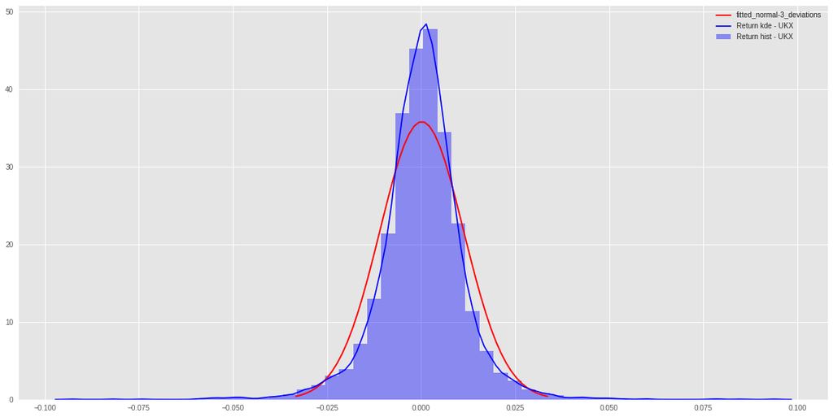

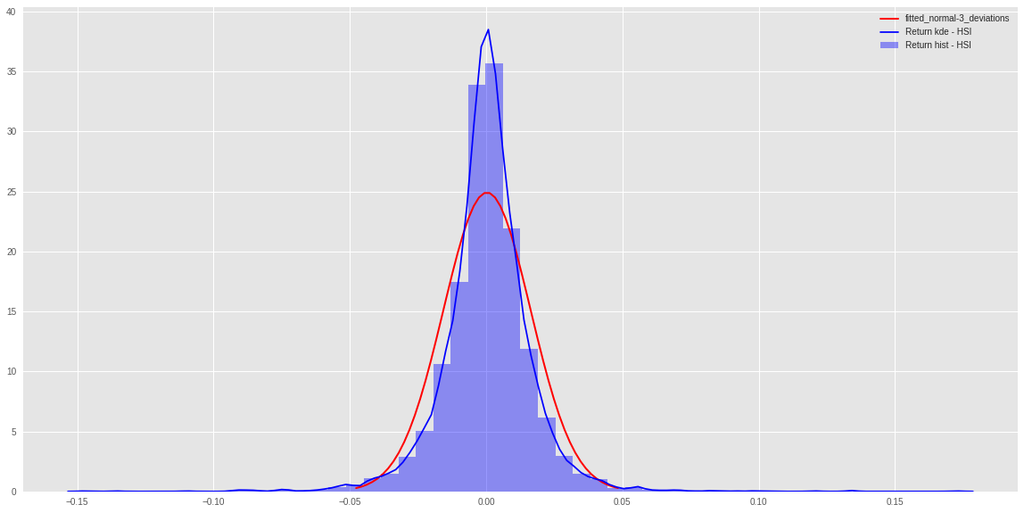

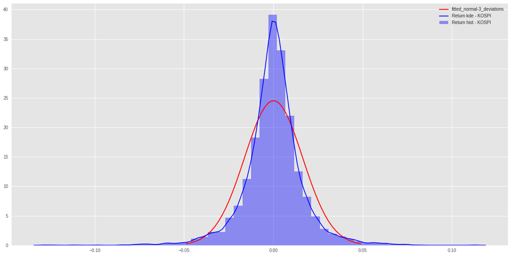

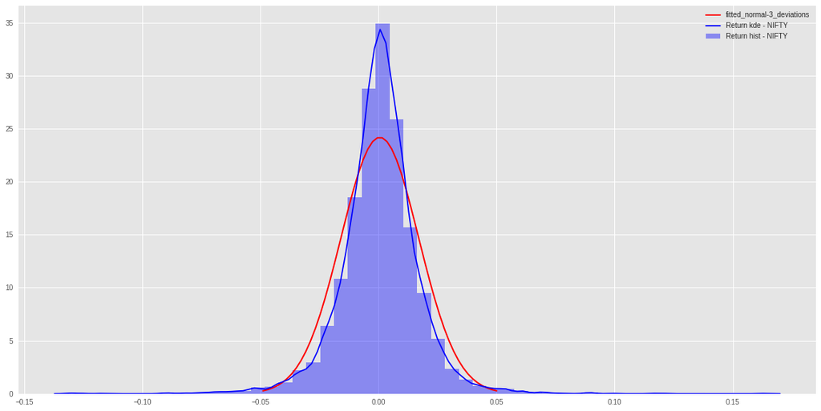

```python
for i in range(0,len(log_returns_data.columns)):
        plot_hist(log_returns_data.iloc[:,i].values, log_returns_data.columns[i])
```

From the above plots we can see that all log-return sets have fat tails on both sides of the distribution. That is all empiral log return sets have high kurtosis as compared to the normal distribution. In addition, the log returns all have somewhat higher peak than the normal distribution. The histograms show the theoretical normal distributions for 3 standard deviations. We can see that the empirical distribution runs wider (higher kurtosis) than the theoretical. Again, this is considered as fat tails.

We can see that this directly contradicts the assumption of normal distribution for log returns.

### Prices - log normal distribution assumption

This section deals with prices and with the log normal distribution assumption. To understand this assumption read the section about assumptions first. That section plots the log normal distribution.

To start with let us have a look at what the distribution for the prices looks like.

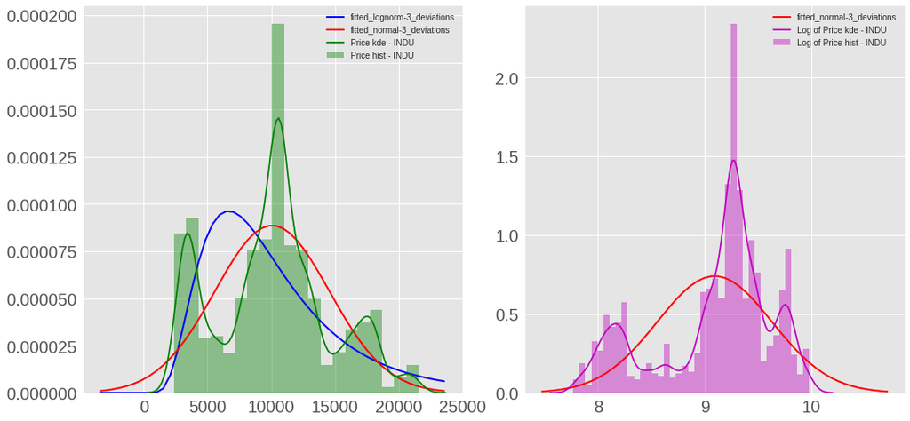

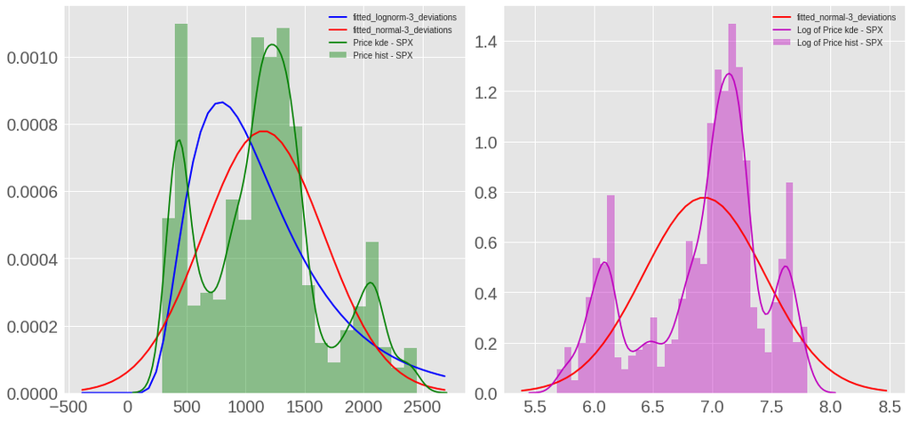

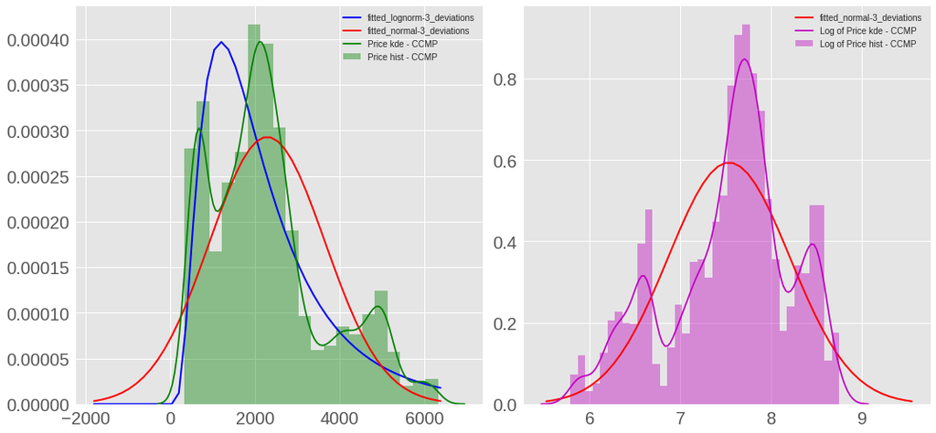

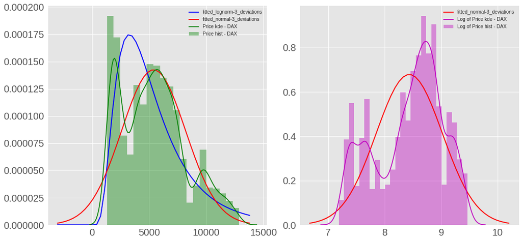

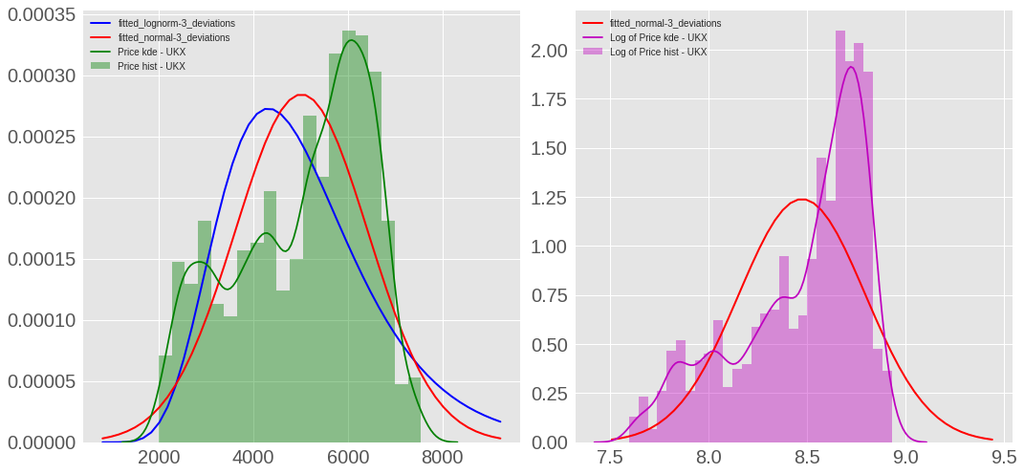

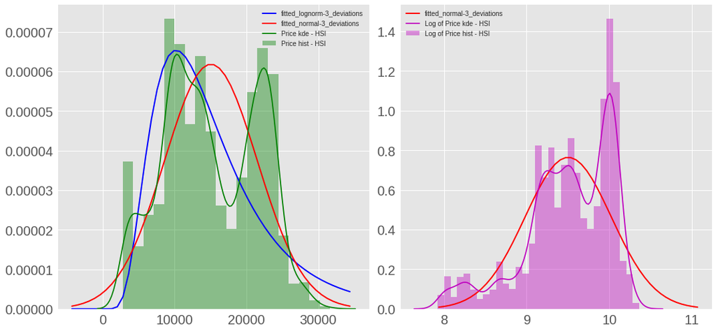

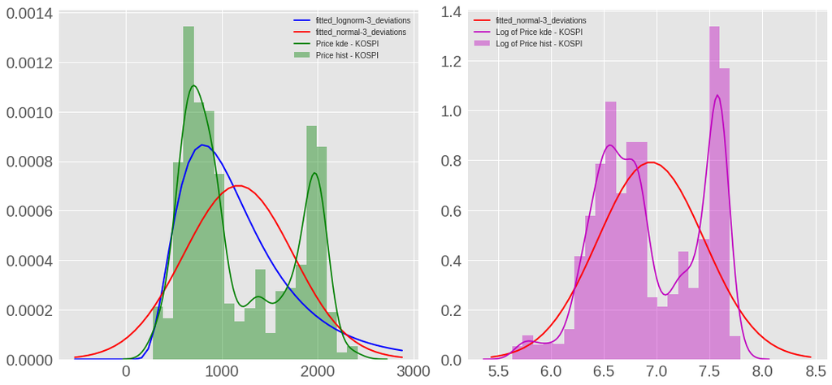

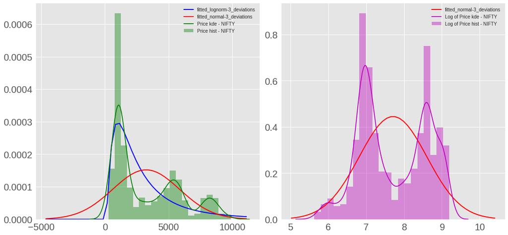

```python
    for i in range (0, len(data.columns)):
        plot_hist_and_log_hist(data.iloc[:,i].unique(), data.columns[i])
```